# NEON_group_project

```r
soil.by.plot.D08 <- full_join(soil.data.sum.DELA, soil.data.sum.LENO)
soil.by.plot.D08 <- full_join(soil.by.plot.D08, soil.data.sum.TALL)
```

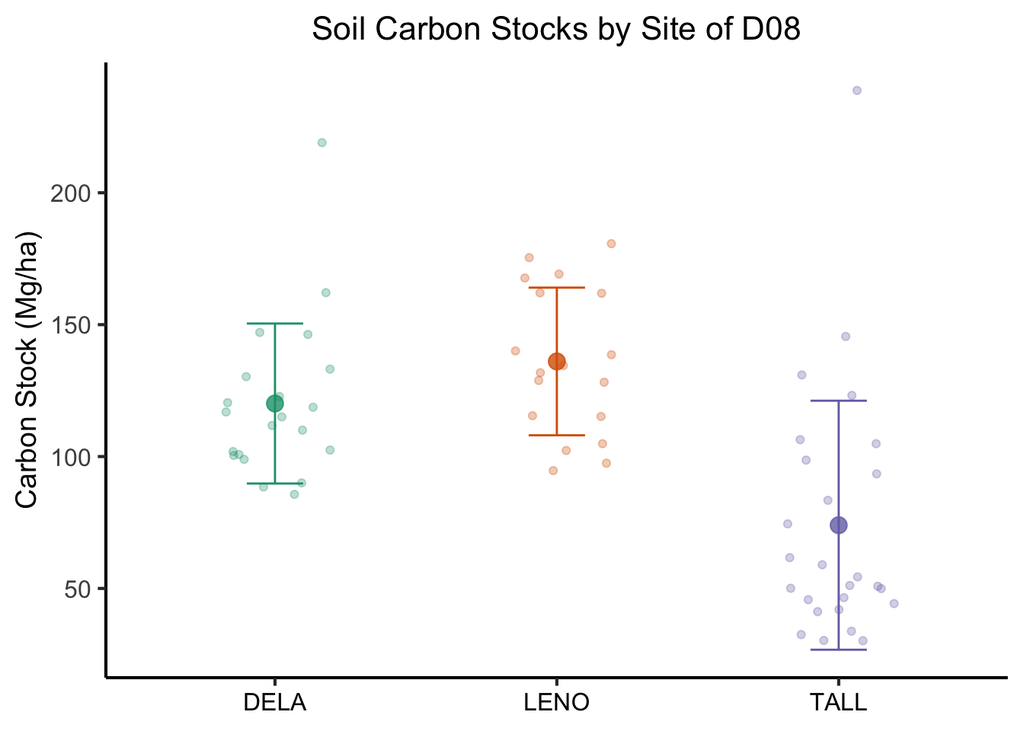

```r
soil.by.plot.D08.summarise <- soil.by.plot.D08 %>%
 group_by(siteID) %>%
 summarise(soil.C.Mg.ha_siteAverage = mean(soil.C.Mg.ha),
           soil.C.Mg.ha_siteSD = sd(soil.C.Mg.ha))

ggplot(data=soil.by.plot.D08, aes(x=siteID, y=soil.C.Mg.ha, group = siteID, color=siteID)) +
  geom_point(size=1.5, alpha = 0.3, position = position_jitterdodge(dodge.width = 0.5))  +
  geom_point(data = soil.by.plot.D08.summarise, aes(x = siteID, y = soil.C.Mg.ha_siteAverage, group = siteID, color=siteID), size = 3.5, alpha = 0.8, position = position_dodge(width = 0.5)) +
  geom_errorbar(data = soil.by.plot.D08.summarise, aes(x= siteID, y = soil.C.Mg.ha_siteAverage, ymin = (soil.C.Mg.ha_siteAverage-soil.C.Mg.ha_siteSD), ymax = (soil.C.Mg.ha_siteAverage+soil.C.Mg.ha_siteSD), colour = siteID), width = 0.2) +
        scale_color_brewer(name = "SiteID", palette = "Dark2") + #color-blind friendly
        ggtitle("Soil Carbon Stocks by Site of D08") +
        ylab("Carbon Stock (Mg/ha)") +
        theme_classic(base_size = 16) +
        theme(plot.title = element_text(size=16, hjust = 0.5),
              axis.text.x=element_text(size=12, color = "black"),
              axis.text.y=element_text(size=12),
              axis.title.y=element_text(size=14),
              axis.title.x=element_blank(),
              legend.text=element_text(size=14),
              legend.title=element_text(size=14),
              legend.position = "none")
```

```r
#Writing the joined dataframe into CSV file
write.csv(soil.by.plot.D08, "soil.by.plot.D08.csv")
```

# Nitrogen!!

## DELA

Downloading the data of interest from NEON, listing, and csvs #COMMENTED OUT

```r
#Loading
# DELA.soil.nitro <- loadByProduct(dpID="DP1.10086.001",
# site=c("DELA","LENO","TALL"),
# startdate="2012-01", enddate="2024-12",
# package="basic")
#
#       list2env(DELA.soil.nitro, .GlobalEnv)
#
#      # spc_biogeochem
#       write.csv(ntr_internalLab, "ntr_internalLab.csv")
#
#      # spc_bulkdensity
#       write.csv(ntr_internalLabBlanks, "ntr_internalLabBlanks.csv")
#
#             #spc_biogeochem
#       write.csv(ntr_externalLab, "ntr_externalLab.csv")
#
#       #spc_bulkdensity
#       write.csv(sls_soilMoisture, "sls_soilMoisture.csv")
```

```r
ntr_internalLab <- read.csv("ntr_internalLab.csv")
ntr_internalLabBlanks <- read.csv("ntr_internalLabBlanks.csv")
ntr_externalLab <- read.csv("ntr_externalLab.csv")
sls_soilMoisture <-read.csv("sls_soilMoisture.csv")

      test.out <- def.calc.ntrans(kclInt = ntr_internalLab, kclIntBlank = ntr_internalLabBlanks, ntr_externalLab, soilMoist = sls_soilMoisture, dropConditions = c("extract stored at incorrect temperature", "soil stored at incorrect temperature", "mass uncertain", "volume uncertain"))
```

```
## [1] "Note: 65 records were missing soil moisture values"
```

```r
data.summary.D08 <- read.csv("datasummary.D08.csv")
str(data.summary.D08)
```

```
## 'data.frame':    443 obs. of  8 variables:
##  $ sampleID                    : chr  "DELA_001-M-0-0-20191112" "DELA_001-M-11-30-20190513" "DELA_001-M-21.5-0-20190626" "DELA_001-M-28-32.5-20190626" ...
##  $ collectDate                 : chr  "2019-11-12 20:17:00" "2019-05-13 20:20:00" "2019-06-26 12:27:00" "2019-06-26 13:06:00" ...
##  $ incubationPairID            : chr  "DELA_001-M-0-0" "DELA_001-M-11-30" "DELA_001-M-21.5-0" "DELA_001-M-28-32.5" ...
##  $ soilAmmoniumNugPerGram      : num  2.37 0.648 0.233 0.328 0.452 0.278 0.706 0.742 0.605 0.698 ...
##  $ soilNitrateNitriteNugPerGram: num  2.713 1.99 0.783 0.93 3.22 ...
##  $ soilInorganicNugPerGram     : num  5.08 2.64 1.02 1.26 3.67 ...
##  $ netNminugPerGramPerDay      : num  0.07 0.093 0.083 0.113 -0.07 0.05 0.196 0.114 0.251 0.107 ...
##  $ netNitugPerGramPerDay       : num  0.134 0.002 0.07 0.12 -0.101 0.049 0.218 0.11 0.258 0.095 ...
```

```r
# Creating variable for siteID aand soil horizon s an independent variable in the dataframe by duplicating sample ID, subsetting the string, separating by the hyphen, and adding back to the original dataframe
data.summary.D08$siteID = substr(data.summary.D08$sampleID, 1,4)
data.summary.D08$siteID_tosplit = substr(data.summary.D08$sampleID, 1,10)
hold.name <- strsplit(data.summary.D08$siteID_tosplit, split="-")
hold.name.df <- as.data.frame(matrix(unlist(hold.name), ncol=2, byrow=T))
colnames(hold.name.df) <- c("plotID", "soilHorizon")
data.summary.D08$plotID <- hold.name.df$plotID
data.summary.D08$soilHorizon <- hold.name.df$soilHorizon

write.csv(data.summary.D08, "data.summary.D08_outputV2.csv")
```

Notably, the Inorganic nitrogen metric provided through the neonNTrans package includes nitrite, which we are not as interested in, but some micorbes being able to utilize it as an intermediate. We could not a clearly identifiable way to isolate nitrate from nitrite with the available data.

#Figures at the plot-level by site

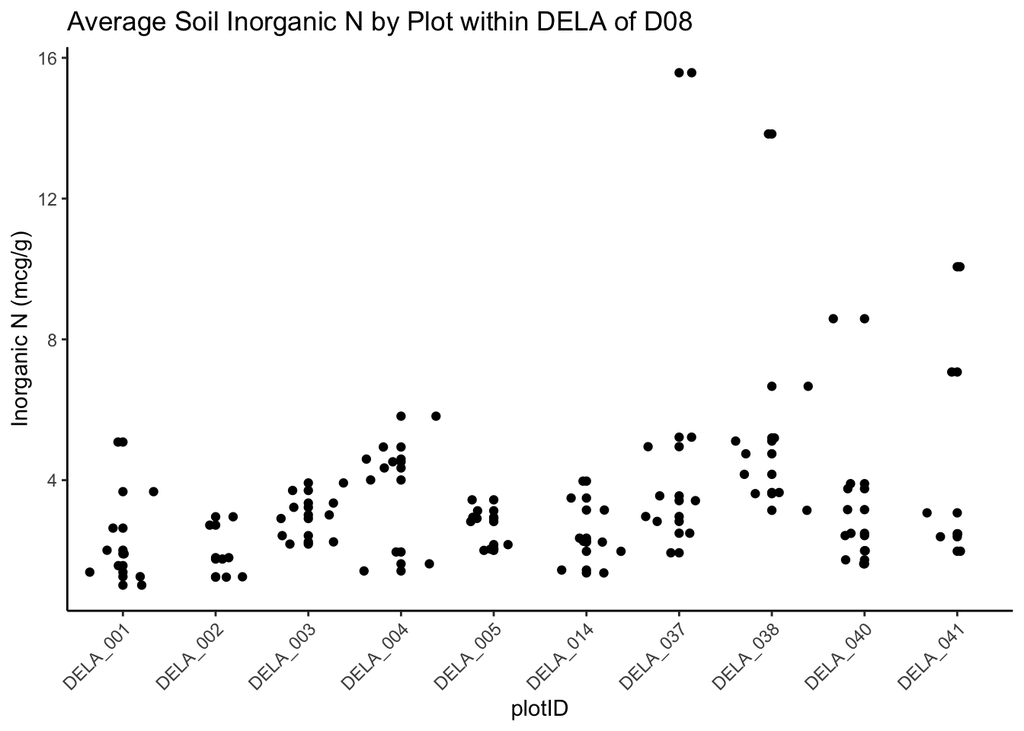

```r
data.summary.D08.DELA <- data.summary.D08 %>%
  filter(siteID == "DELA")
data.summary.D08.LENO <- data.summary.D08 %>%
  filter(siteID == "LENO")
data.summary.D08.TALL <- data.summary.D08 %>%
  filter(siteID == "TALL")

exploratory.InorgN.DELA.plot <- ggplot(data=data.summary.D08.DELA, aes(x=plotID, y=soilInorganicNugPerGram)) +
  geom_point(size=1.5, alpha = 1)  +
        #scale_color_brewer(name = "SiteID", palette = "Dark2") + #color-blind friendly
        ggtitle("Average Soil Inorganic N by Plot within DELA of D08") +
       #scale_y_continuous(breaks = seq(0, 100, 10), limits = c(-15, 100)) +
        ylab("Inorganic N (mcg/g)") +
     geom_jitter() +
    theme_classic() +
  theme(axis.text.x = element_text(angle = 45, vjust = 1, hjust=1))
exploratory.InorgN.DELA.plot
```

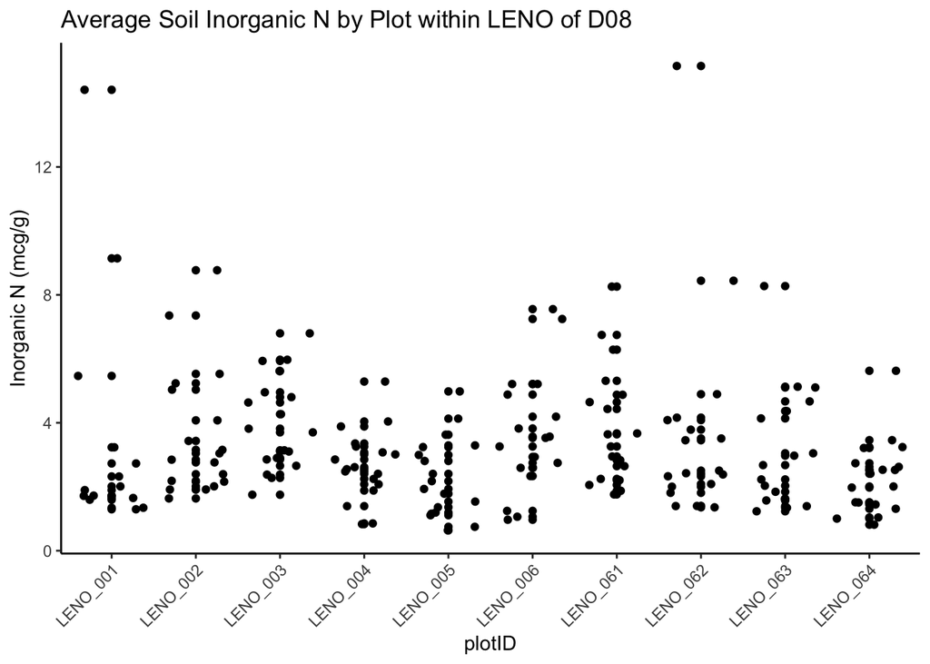

```r
exploratory.InorgN.LENO.plot <- ggplot(data=data.summary.D08.LENO, aes(x=plotID, y=soilInorganicNugPerGram)) +
  geom_point(size=1.5, alpha = 1)  +
        #scale_color_brewer(name = "SiteID", palette = "Dark2") + #color-blind friendly
        ggtitle("Average Soil Inorganic N by Plot within LENO of D08") +
       #scale_y_continuous(breaks = seq(0, 100, 10), limits = c(-15, 100)) +
        ylab("Inorganic N (mcg/g)") +
     geom_jitter() +
    theme_classic() +
  theme(axis.text.x = element_text(angle = 45, vjust = 1, hjust=1))
exploratory.InorgN.LENO.plot
```

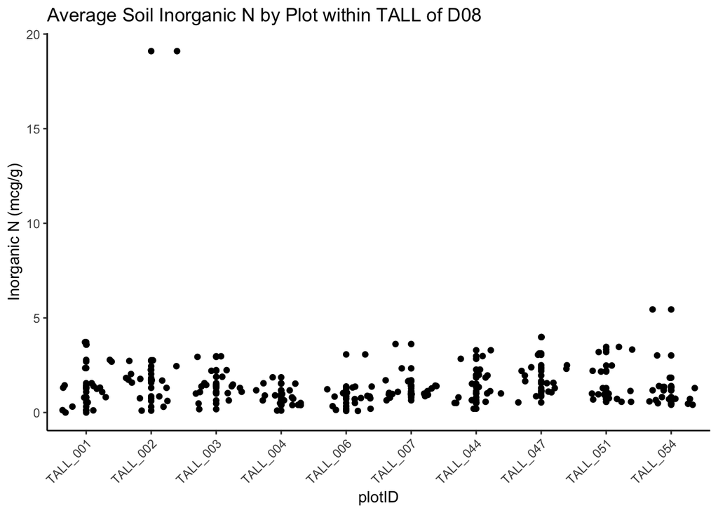

```r
exploratory.InorgN.TALLplot <- ggplot(data=data.summary.D08.TALL, aes(x=plotID, y=soilInorganicNugPerGram)) +
  geom_point(size=1.5, alpha = 1)  +
        #scale_color_brewer(name = "SiteID", palette = "Dark2") + #color-blind friendly
        ggtitle("Average Soil Inorganic N by Plot within TALL of D08") +
       #scale_y_continuous(breaks = seq(0, 100, 10), limits = c(-15, 100)) +
        ylab("Inorganic N (mcg/g)") +
     geom_jitter() +
    theme_classic() +
  theme(axis.text.x = element_text(angle = 45, vjust = 1, hjust=1))
exploratory.InorgN.TALLplot
```

#Figures at the site-level

```r
# Initial visualization of data for Inorganic N
data.summary.D08.Exploratory <- data.summary.D08 %>%
 group_by(siteID) %>%
 summarise(soilInorganicNugPerGram_average = mean(soilInorganicNugPerGram),
           soilInorganicNugPerGram_sd = sd(soilInorganicNugPerGram))

exploratory.InorgN.D08 <- ggplot(data=data.summary.D08, aes(x=siteID, y=soilInorganicNugPerGram, group = siteID, color=siteID)) +
  geom_point(size=1.5, alpha = 0.3, position = position_jitterdodge(dodge.width = 0.5))  +
  geom_point(data = data.summary.D08.Exploratory, aes(x = siteID, y = soilInorganicNugPerGram_average, group = siteID, color=siteID), size = 3.5, alpha = 0.8, position = position_dodge(width = 0.5)) +
  geom_errorbar(data = data.summary.D08.Exploratory, aes(x= siteID, y = soilInorganicNugPerGram_average, ymin = (soilInorganicNugPerGram_average-soilInorganicNugPerGram_sd), ymax = (soilInorganicNugPerGram_average+soilInorganicNugPerGram_sd), colour = siteID), width = 0.2) +
        scale_color_brewer(name = "SiteID", palette = "Dark2") + #color-blind friendly
        ggtitle("Average Soil Inorganic N (ug/gram) by Site of D08") +
       scale_y_continuous(breaks = seq(0, 100, 10), limits = c(-15, 100)) +
        ylab("Inorganic N (mcg/g)") +
        theme_classic(base_size = 16) +
        theme(plot.title = element_text(size=16, hjust = 0.5),
              axis.text.x=element_text(size=12, color = "black"),
              axis.text.y=element_text(size=12),
              axis.title.y=element_text(size=14),
              axis.title.x=element_blank(),
              legend.text=element_text(size=14),
              legend.title=element_text(size=14),
              legend.position = "none")

# Initial visualization of data for Ammonium
data.summary.D08.Exploratory.NH4 <- data.summary.D08 %>%
 group_by(siteID) %>%
 summarise(soilAmmoniumNugPerGram_average = mean(soilAmmoniumNugPerGram),
           soilAmmoniumNugPerGram_sd = sd(soilAmmoniumNugPerGram))

# exploratory.ammonium.D08 <- ggplot(data=data.summary.D08, aes(x=siteID, y=soilAmmoniumNugPerGram, group = siteID, color=siteID)) +
#   geom_point(size=1.5, alpha = 0.3, position = position_jitterdodge(dodge.width = 0.5))  +
#   geom_point(data = data.summary.D08.Exploratory.NH4, aes(x = siteID, y = soilAmmoniumNugPerGram_average, group = siteID, color=siteID), size = 3.5, alpha = 0.8, position = position_dodge(width = 0.5)) +
#   geom_errorbar(data = data.summary.D08.Exploratory.NH4, aes(x= siteID, y = soilAmmoniumNugPerGram_average, ymin = (soilAmmoniumNugPerGram_average-soilAmmoniumNugPerGram_sd), ymax = (soilAmmoniumNugPerGram_average+soilAmmoniumNugPerGram_sd), colour = siteID), width = 0.2) +
#         scale_color_brewer(name = "SiteID", palette = "Dark2") + #color-blind friendly
#         ggtitle("Average Soil Ammonium (ug/gram) by Site of D08") +
#        scale_y_continuous(breaks = seq(-10, 80, 10), limits = c(-10, 65)) +
#       scale_y_break(c(32, 48)) +
#         ylab("Ammonium (mcg/g)") +
#         theme_classic(base_size = 16) +
#         theme(plot.title = element_text(size=16, hjust = 0.5),
#               axis.text.x=element_text(size=12, color = "black"),
#               axis.text.y=element_text(size=12),
#               axis.title.y=element_text(size=14),
#               axis.title.x=element_blank(),
#               axis.text.y.right = element_blank(), #deals with weird ggbreak glitch
#               axis.line.y.right = element_blank(), #deals with weird ggbreak glitch
#               axis.ticks.y.right = element_blank(), #deals with weird ggbreak glitch
#               legend.text=element_text(size=14),
#               legend.title=element_text(size=14),
#               legend.position = "none")
#
# exploratory.InorgN.D08
# exploratory.ammonium.D08
#
# # Initial visualization of data for Mineralization
# data.summary.D08.Exploratory.Mineralization <- data.summary.D08 %>%
#  group_by(siteID) %>%
#  summarise(netNminugPerGramPerDay_average = mean(netNminugPerGramPerDay), #averaging a rate, always messes with my head if appropriately statistically
#            netNminugPerGramPerDay_sd = sd(netNminugPerGramPerDay))
#
# exploratory.mineralization.D08 <- ggplot(data=data.summary.D08, aes(x=siteID, y=netNminugPerGramPerDay, group = siteID, color=siteID)) +
#   geom_point(size=1.5, alpha = 0.3, position = position_jitterdodge(dodge.width = 0.5))  +
#   geom_point(data = data.summary.D08.Exploratory.Mineralization, aes(x = siteID, y = netNminugPerGramPerDay_average, group = siteID, color=siteID), size = 3.5, alpha = 0.8, position = position_dodge(width = 0.5)) +
#   geom_errorbar(data = data.summary.D08.Exploratory.Mineralization, aes(x= siteID, y = netNminugPerGramPerDay_average, ymin = (netNminugPerGramPerDay_average-netNminugPerGramPerDay_sd), ymax = (netNminugPerGramPerDay_average+netNminugPerGramPerDay_sd), colour = siteID), width = 0.2) +
#         scale_color_brewer(name = "SiteID", palette = "Dark2") + #color-blind friendly
#         ggtitle("Average Soil N Mineralization rate ((ug/gram)/day) by Site of D08") +
#        #scale_y_continuous(breaks = seq(-10, 80, 10), limits = c(-10, 65)) +
#      # scale_y_break(c(32, 48)) +
#         ylab("Mineralization ((mcg/g)/day)") +
#         theme_classic(base_size = 16) +
#         theme(plot.title = element_text(size=16, hjust = 0.5),
#               axis.text.x=element_text(size=12, color = "black"),
#               axis.text.y=element_text(size=12),
#               axis.title.y=element_text(size=14),
#               axis.title.x=element_blank(),
#              #axis.text.y.right = element_blank(), #deals with weird ggbreak glitch
#               #axis.line.y.right = element_blank(), #deals with weird ggbreak glitch
#               #axis.ticks.y.right = element_blank(), #deals with weird ggbreak glitch
#               legend.text=element_text(size=14),
#               legend.title=element_text(size=14),
#               legend.position = "none")
#
# exploratory.mineralization.D08 #note, getting a missing values warning
```

```r
D08.nitrogen.df <- read.csv("data.summary.D08_outputV2.csv")
str(D08.nitrogen.df) #443 observations
```

```
## 'data.frame':    443 obs. of  13 variables:
##  $ X                           : int  1 2 3 4 5 6 7 8 9 10 ...
##  $ sampleID                    : chr  "DELA_001-M-0-0-20191112" "DELA_001-M-11-30-20190513" "DELA_001-M-21.5-0-20190626" "DELA_001-M-28-32.5-20190626" ...
##  $ collectDate                 : chr  "2019-11-12 20:17:00" "2019-05-13 20:20:00" "2019-06-26 12:27:00" "2019-06-26 13:06:00" ...
##  $ incubationPairID            : chr  "DELA_001-M-0-0" "DELA_001-M-11-30" "DELA_001-M-21.5-0" "DELA_001-M-28-32.5" ...
##  $ soilAmmoniumNugPerGram      : num  2.37 0.648 0.233 0.328 0.452 0.278 0.706 0.742 0.605 0.698 ...
##  $ soilNitrateNitriteNugPerGram: num  2.713 1.99 0.783 0.93 3.22 ...
##  $ soilInorganicNugPerGram     : num  5.08 2.64 1.02 1.26 3.67 ...
##  $ netNminugPerGramPerDay      : num  0.07 0.093 0.083 0.113 -0.07 0.05 0.196 0.114 0.251 0.107 ...
##  $ netNitugPerGramPerDay       : num  0.134 0.002 0.07 0.12 -0.101 0.049 0.218 0.11 0.258 0.095 ...
##  $ siteID                      : chr  "DELA" "DELA" "DELA" "DELA" ...
##  $ siteID_tosplit              : chr  "DELA_001-M" "DELA_001-M" "DELA_001-M" "DELA_001-M" ...
##  $ plotID                      : chr  "DELA_001" "DELA_001" "DELA_001" "DELA_001" ...
##  $ soilHorizon                 : chr  "M" "M" "M" "M" ...
```